# Analysis and Graph Generation

Tan Kia Leng

2023-11-02

```r
library(tidyverse)
library(afex)
library(emmeans)
```

## Reading in dataset

```r
## Converting data source from sav to csv
# haven::read_sav("raw/Dataset (1).sav") %>%
#   write.csv("data/data_raw (from sav).csv",row.names=FALSE)

data <- read_csv("data/data_raw (from sav).csv")
```

## Data Cleaning, selection of variables

Use ends_with to select variables of concern.

Note: Columns where conditions are NA are removed. - Should print information in output

```r
vars_of_interest <- c("success","stress","opt","RFS_pro","RFS_pre")
select_vars <- function(data,vars_of_interest) {
  suffix <- paste0("[0-9]_",vars_of_interest,"$")
  selected <- data %>%
    select(ID, Condition, matches(suffix))
  return(selected)
}

data_req <- select_vars(data,vars_of_interest = vars_of_interest)
```

## Time Manipulation

Output: One row represents each level of Intervention-Time for each individual, in tidy format e.g. Promotion-S3-Individual-1 in each role

```r
rename_cols <- function(data) {
  data %>% rename("Success" = "success",
           "Stress" = "stress",
           "Optimism" = "opt",
           "RFS_Promotion" = "RFS_pro",
           "RFS_Prevention" = "RFS_pre",
           "Intervention" = "Condition")
}

current_period <- function(data) {
  data %>%
    pivot_longer(cols= matches(vars_of_interest),
                 names_to=c("Time","Var"),values_to=c("Value"),
                 names_pattern=('(S[1-9])_(.*)')) %>%
    pivot_wider(names_from = Var, values_from = Value) %>% rename_cols()  %>%

    mutate(Intervention_Pro = ifelse(str_detect(Intervention,c("Promotion|Combined")),1,0),
         Intervention_Pre = ifelse(str_detect(Intervention,c("Prevention|Combined")),1,0),
         .after = "Intervention"
         )
}

data_pred_curr <- current_period(data_req)

predictors <- c("stress","opt","RFS_pre","RFS_pro")
dv <- c("success")


future_pred <- function(data, predictors,dv) {
  data_req %>%
    # pivot variables longer to have one row rep var-time pair
    pivot_longer(cols= matches(vars_of_interest),
                   names_to=c("Time","Var"),values_to=c("Value"),
                   names_pattern=('(S[1-9])_(.*)')) %>%
    # drop success at S1 and predicotrs at S5
    mutate(Time = as.numeric(str_extract(Time,"[0-9]")),
           keep = ((Var %in% predictors) &(Time<5))|((Var %in% dv) &(Time>1))) %>%
    filter(keep == TRUE) %>%
    mutate(keep = NULL,

    # match predictors at previous time to success at curr time
           is_predictor = Var %in% predictors,
           pred_for = case_when(
             is_predictor ~ paste0("S",ifelse(Time+1==2,3,Time+1)),
             TRUE ~ paste0("S",Time)),
           is_predictor=NULL) %>%
    pivot_wider(values_from=c(Time,Value),names_from = Var) %>%
    rename_with(~ str_remove(.x,"Value_")) %>%

    rename_cols() %>%
    mutate(Intervention_Pro = ifelse(str_detect(Intervention,c("Promotion|Combined")),1,0),
           Intervention_Pre = ifelse(str_detect(Intervention,c("Prevention|Combined")),1,0),
           .after = "Intervention"
           )
}

data_pred_future <- future_pred(data_req,predictors,dv)
```

```r
filter_condition <- function(data, conditions_to_keep) {
  data %>%
    filter(Intervention %in% conditions_to_keep)
}
```

```r
data_pred_future %>%
  select(Intervention,RFS_Promotion,Optimism,RFS_Prevention,Stress,Success)
```

```
## # A tibble: 1,200 × 6
##    Intervention     RFS_Promotion Optimism RFS_Prevention Stress Success
##    <chr>                    <dbl>    <dbl>          <dbl>  <dbl>   <dbl>
##  1 Promotion Focus           3.5      3.45           3.83   2       3.46
##  2 Promotion Focus           4        3.27           2.83   2.89    3.79
##  3 Promotion Focus           3.5      3.55           3      3.78    3.92
##  4 Control                   3.62     4.45           4.67   4.56    3.62
##  5 Control                   4.25     4.09           3.5    4.22    4.21
##  6 Control                   3.62     4.45           4.17   4.11   NA
##  7 Combined Focus            3.75     3.64           3.17   4.11    3.75
##  8 Combined Focus            4        3.55           2.33   3.56    3.42
##  9 Combined Focus            3.88     3.64           2.17   2.89    3.71
## 10 Prevention Focus          3        2.09           3.67   3.56    2.75
## # … with 1,190 more rows
```

```r
data_for_corrs <- data_pred_future %>%
  select(Intervention_Pro,RFS_Promotion,Optimism,
         Intervention_Pre,RFS_Prevention,Stress,
         Success)
correlations <- cor(data_for_corrs,use="pairwise.complete.obs")
# write.csv(correlations,file="correlations.csv")
```

## Plot

```r
mean_two_sd_optimism <- function(data) {
  mean_opt <- mean(data$Optimism,na.rm=TRUE)
  sd_opt <- sd(data$Optimism,na.rm=TRUE)

  return (c("Low"= mean_opt-2*sd_opt,
            "Medium" = mean_opt,
            "High" = mean_opt+2*sd_opt))
}

mean_two_sd_stress <- function(data) {
  mean_stress <- mean(data$Stress,na.rm=TRUE)
  sd_stress <- sd(data$Stress,na.rm=TRUE)

  return (c("Low"= mean_stress-2*sd_stress,
            "Medium" = mean_stress,
            "High" = mean_stress+2*sd_stress))
}
```

## ANOVA

```r
intv_pro_opt_model <- function(data) {
  print(data)
  lm(Success ~ Intervention*Optimism, data = data)
}

presence_pro_opt_model <- function(data) {
  lm(Success ~ Intervention_Pro*Optimism, data = data)
}

rfs_pro_opt_model <- function(data) {
  lm(Success ~ RFS_Promotion*Optimism, data = data)
}


intv_pre_stress_model <- function(data) {
  print(data)
  lm(Success ~ Intervention*Stress, data = data)
}

presence_pre_stress_model <- function(data) {
  lm(Success ~ Intervention_Pre*Stress, data = data)
}


rfs_pre_stress_model <- function(data) {
  lm(Success ~ RFS_Prevention*Stress, data = data)
}
```

## Correlation of data at the same time point

How do interventions, regulatory focus strategies, optimism and stress level relate to feelings of success at any time points?

Note: purely correlational

Within the same time, feelings of success and optimism levels were measured after

InterPro x Opt –> Success

### Pro

#### Current

```r
data <- data_pred_curr %>%
  filter_condition(c("Promotion Focus","Control")) %>%
  filter(Time != "S1")

intv_pro_opt_curr <-intv_pro_opt_model(data)
```

```
## # A tibble: 597 × 10
##       ID Interven…¹ Inter…² Inter…³ Time  Success Stress Optim…⁴ RFS_P…⁵ RFS_P…⁶
##    <dbl> <chr>        <dbl>   <dbl> <chr>   <dbl>  <dbl>   <dbl>   <dbl>   <dbl>
##  1     1 Promotion…       1       0 S3       3.46   2.89    3.27    4       2.83
##  2     1 Promotion…       1       0 S4       3.79   3.78    3.55    3.5     3
##  3     1 Promotion…       1       0 S5       3.92   3.44    3.82    3.88    3.17
##  4     2 Control          0       0 S3       3.62   4.22    4.09    4.25    3.5
##  5     2 Control          0       0 S4       4.21   4.11    4.45    3.62    4.17
##  6     2 Control          0       0 S5      NA     NA      NA      NA      NA
##  7     6 Promotion…       1       0 S3       3.04   3.56    2.64    3.62    3
##  8     6 Promotion…       1       0 S4       3.62   4.33    2.64    4       4
##  9     6 Promotion…       1       0 S5       3.42   4.56    2.73    4.62    3.33
## 10     7 Control          0       0 S3       3.58   3.89    2.91    3.75    3.67
## # … with 587 more rows, and abbreviated variable names ¹Intervention,
## #   ²Intervention_Pro, ³Intervention_Pre, ⁴Optimism, ⁵RFS_Promotion,
## #   ⁶RFS_Prevention
```

```r
summary(intv_pro_opt_curr)
```

```
##
## Call:
## lm(formula = Success ~ Intervention * Optimism, data = data)
##
## Residuals:
##      Min       1Q   Median       3Q      Max
## -1.57938 -0.22711  0.03667  0.24491  1.33198
##
## Coefficients:
##                                      Estimate Std. Error t value Pr(>|t|)
## (Intercept)                           2.06826    0.12274  16.851   <2e-16 ***
## InterventionPromotion Focus           0.35553    0.17366   2.047   0.0411 *
## Optimism                              0.50278    0.03848  13.067   <2e-16 ***
## InterventionPromotion Focus:Optimism -0.08440    0.05472  -1.542   0.1236
## ---
## Signif. codes:  0 '***' 0.001 '**' 0.01 '*' 0.05 '.' 0.1 ' ' 1
##
## Residual standard error: 0.392 on 514 degrees of freedom
##   (79 observations deleted due to missingness)
## Multiple R-squared:  0.362,  Adjusted R-squared:  0.3582
## F-statistic: 97.19 on 3 and 514 DF,  p-value: < 2.2e-16
```

```r
emm <- emmeans(intv_pro_opt_curr, ~ Intervention | Optimism,
        at = list(Optimism=mean_two_sd_optimism(data)))
pairs(emm)
```

```
## Optimism = 1.85:
##  contrast                  estimate     SE  df t.ratio p.value
##  Control - Promotion Focus  -0.1994 0.0771 514  -2.586  0.0100
##
## Optimism = 3.11:
##  contrast                  estimate     SE  df t.ratio p.value
##  Control - Promotion Focus  -0.0930 0.0345 514  -2.699  0.0072
##
## Optimism = 4.37:
##  contrast                  estimate     SE  df t.ratio p.value
##  Control - Promotion Focus   0.0134 0.0771 514   0.174  0.8623
```

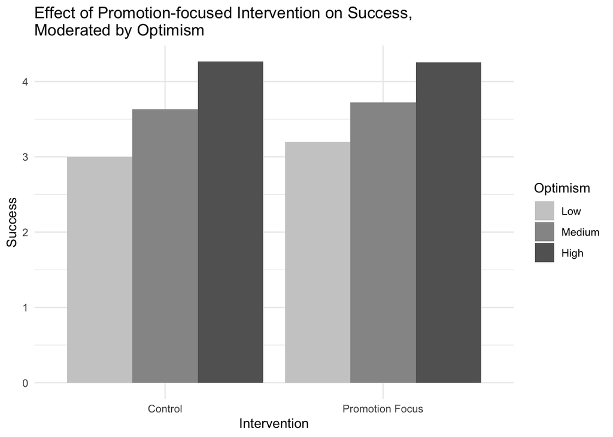

```r
plot_data <- data.frame(
  Intervention = rep(sort(unique(data$Intervention)),each=3),
  Optimism = rep(mean_two_sd_optimism(data),times=2),
  Optimism_Level = rep(names(mean_two_sd_optimism(data)),times=2)
  ) %>%
  mutate(Intervention = factor(Intervention,levels=c("Control","Promotion Focus")),
         Optimism_Level = factor(Optimism_Level,levels=c("Low","Medium","High")))


plot_data$Success <- predict(intv_pro_opt_curr,plot_data)

ggplot(plot_data) +
  geom_col(aes(x=Intervention,y=Success,fill=Optimism_Level),position = "dodge") +
  scale_fill_manual(values = c("Low" = "#CCCCCC", "Medium" = "#969696", "High" = "#636363")) +
  labs(title = "Effect of Promotion-focused Intervention on Success, \
Moderated by Optimism",
       x = "Intervention", y = "Success",fill="Optimism") +
  theme_minimal()
```

```r
data <- data_pred_curr %>%
  filter(Time != "S1")

presence_pro_opt_curr <- presence_pro_opt_model(data)
summary(presence_pro_opt_curr)
```

```
##
## Call:
## lm(formula = Success ~ Intervention_Pro * Optimism, data = data)
##
## Residuals:
##      Min       1Q   Median       3Q      Max
## -1.96647 -0.24199  0.02912  0.26828  1.35161
##
## Coefficients:
##                           Estimate Std. Error t value Pr(>|t|)
## (Intercept)                1.83039    0.08915  20.531  < 2e-16 ***
## Intervention_Pro           0.36683    0.12914   2.840  0.00459 **
## Optimism                   0.57137    0.02819  20.267  < 2e-16 ***
## Intervention_Pro:Optimism -0.08822    0.04069  -2.168  0.03038 *
## ---
## Signif. codes:  0 '***' 0.001 '**' 0.01 '*' 0.05 '.' 0.1 ' ' 1
##
## Residual standard error: 0.414 on 1053 degrees of freedom
##   (143 observations deleted due to missingness)
## Multiple R-squared:  0.3992, Adjusted R-squared:  0.3975
## F-statistic: 233.2 on 3 and 1053 DF,  p-value: < 2.2e-16
```

```r
emm <- emmeans(presence_pro_opt_curr, ~ Intervention_Pro | Optimism,
        at = list(Optimism=mean_two_sd_optimism(data)))
pairs(emm)
```

```
## Optimism = 1.86:
##  contrast                              estimate     SE   df t.ratio p.value
##  Intervention_Pro0 - Intervention_Pro1  -0.2030 0.0570 1053  -3.559  0.0004
##
## Optimism = 3.11:
##  contrast                              estimate     SE   df t.ratio p.value
##  Intervention_Pro0 - Intervention_Pro1  -0.0924 0.0255 1053  -3.626  0.0003
##
## Optimism = 4.36:
##  contrast                              estimate     SE   df t.ratio p.value
##  Intervention_Pro0 - Intervention_Pro1   0.0182 0.0570 1053   0.320  0.7492
```

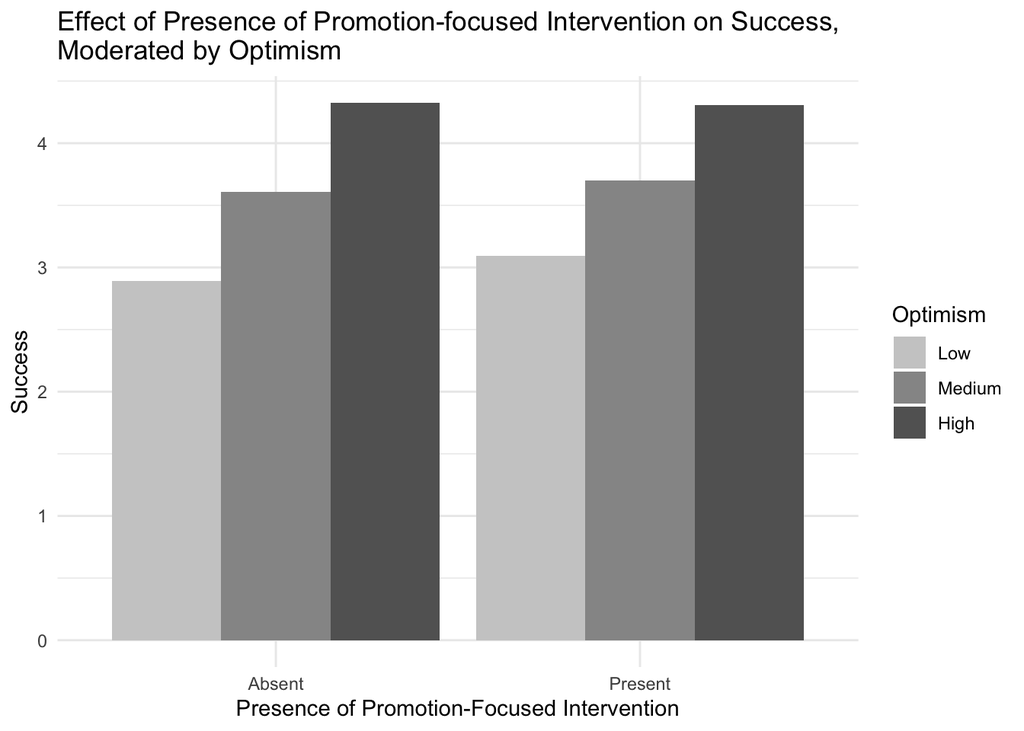

```r
plot_data <- data.frame(
  Intervention_Pro = rep(c(0,1),each=3),
  Optimism = rep(mean_two_sd_optimism(data),times=2),
  Optimism_Level = rep(names(mean_two_sd_optimism(data)),times=2)
  ) %>%
  mutate(Optimism_Level = factor(Optimism_Level,levels=c("Low","Medium","High")))


plot_data$Success <- predict(presence_pro_opt_curr,plot_data)
plot_data$Intervention_Pro <- ifelse(plot_data$Intervention_Pro == 0,"Absent","Present")

ggplot(plot_data) +
  geom_col(aes(x=Intervention_Pro,y=Success,fill=Optimism_Level),position = "dodge") +
  scale_fill_manual(values = c("Low" = "#CCCCCC", "Medium" = "#969696", "High" = "#636363")) +
  labs(title = "Effect of Presence of Promotion-focused Intervention on Success,\
Moderated by Optimism",
       x = "Presence of Promotion-Focused Intervention", y = "Success",fill="Optimism") +
  theme_minimal()
```

```r
rfs_pro_opt_curr <- rfs_pro_opt_model(data_pred_curr)
summary(rfs_pro_opt_curr)
```

```
##
## Call:
## lm(formula = Success ~ RFS_Promotion * Optimism, data = data)
##
## Residuals:
##      Min       1Q   Median       3Q      Max
## -1.91218 -0.25325  0.02053  0.28253  1.45970
##
## Coefficients:
##                        Estimate Std. Error t value Pr(>|t|)
## (Intercept)             2.69290    0.37213   7.237 7.43e-13 ***
## RFS_Promotion          -0.18102    0.09692  -1.868   0.0620 .
## Optimism                0.23926    0.12144   1.970   0.0490 *
## RFS_Promotion:Optimism  0.07541    0.03121   2.416   0.0158 *
## ---
## Signif. codes:  0 '***' 0.001 '**' 0.01 '*' 0.05 '.' 0.1 ' ' 1
##
## Residual standard error: 0.4216 on 1453 degrees of freedom
##   (143 observations deleted due to missingness)
## Multiple R-squared:  0.3978, Adjusted R-squared:  0.3965
## F-statistic: 319.9 on 3 and 1453 DF,  p-value: < 2.2e-16
```

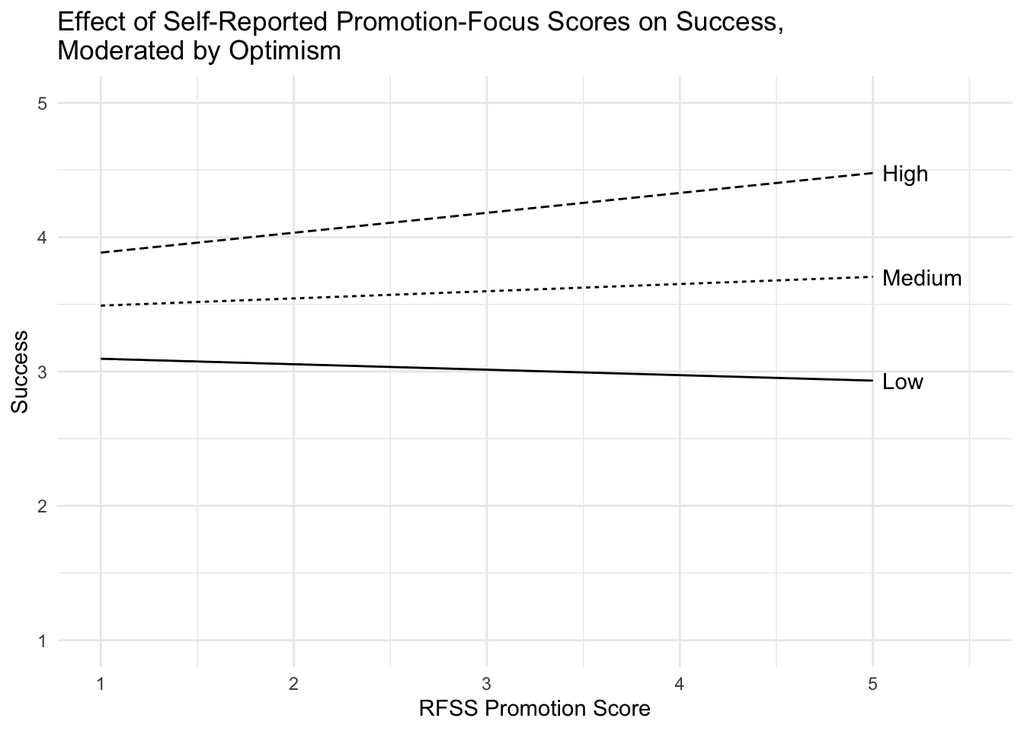

```r
plot_data <- data.frame(
  RFS_Promotion = rep(c(1,5),each=3),
  Optimism = rep(mean_two_sd_optimism(data),times=2),
  Optimism_Level = rep(names(mean_two_sd_optimism(data)),times=2)
  ) %>%
  mutate(Optimism_Level = factor(Optimism_Level,levels=c("Low","Medium","High")))


plot_data$Success <- predict(rfs_pro_opt_curr,plot_data)


ggplot(plot_data) +
  geom_path(aes(x=RFS_Promotion,y=Success,linetype=Optimism_Level), show.legend=FALSE) +
  geom_text(aes(x=RFS_Promotion,y=Success,label=Optimism_Level), nudge_x = 0.05,hjust=0,
            data = filter(plot_data, RFS_Promotion == 5)) +
  scale_x_continuous(limits = c(1, 5.5)) +
  scale_y_continuous(limits = c(1,5)) +
  labs(title = "Effect of Self-Reported Promotion-Focus Scores on Success, \
Moderated by Optimism",
       x = "RFSS Promotion Score", y = "Success") +
  theme_minimal()
```

#### Predictions

```r
data <- data_pred_future %>%
  filter_condition(c("Promotion Focus","Control"))
intv_pro_opt_future <- intv_pro_opt_model(data)
```

```
## # A tibble: 597 × 15
##       ID Inter…¹ Inter…² Inter…³ pred_…⁴ Time_…⁵ Time_…⁶ Time_…⁷ Time_…⁸ Time_…⁹
##    <dbl> <chr>     <dbl>   <dbl> <chr>     <dbl>   <dbl>   <dbl>   <dbl>   <dbl>
##  1     1 Promot…       1       0 S3            3       1       1       1       1
##  2     1 Promot…       1       0 S4            4       3       3       3       3
##  3     1 Promot…       1       0 S5            5       4       4       4       4
##  4     2 Control       0       0 S3            3       1       1       1       1
##  5     2 Control       0       0 S4            4       3       3       3       3
##  6     2 Control       0       0 S5            5       4       4       4       4
##  7     6 Promot…       1       0 S3            3       1       1       1       1
##  8     6 Promot…       1       0 S4            4       3       3       3       3
##  9     6 Promot…       1       0 S5            5       4       4       4       4
## 10     7 Control       0       0 S3            3       1       1       1       1
## # … with 587 more rows, 5 more variables: Success <dbl>, Stress <dbl>,
## #   Optimism <dbl>, RFS_Promotion <dbl>, RFS_Prevention <dbl>, and abbreviated
## #   variable names ¹Intervention, ²Intervention_Pro, ³Intervention_Pre,
## #   ⁴pred_for, ⁵Time_success, ⁶Time_stress, ⁷Time_opt, ⁸Time_RFS_pro,
## #   ⁹Time_RFS_pre
```

```r
summary(intv_pro_opt_future)
```

```
##
## Call:
## lm(formula = Success ~ Intervention * Optimism, data = data)
##
## Residuals:
##      Min       1Q   Median       3Q      Max
## -1.79891 -0.25542  0.03247  0.29075  1.37087
##
## Coefficients:
##                                      Estimate Std. Error t value Pr(>|t|)
## (Intercept)                           2.43588    0.13947  17.465   <2e-16 ***
## InterventionPromotion Focus           0.46501    0.19378   2.400   0.0168 *
## Optimism                              0.38605    0.04384   8.807   <2e-16 ***
## InterventionPromotion Focus:Optimism -0.12033    0.06127  -1.964   0.0501 .
## ---
## Signif. codes:  0 '***' 0.001 '**' 0.01 '*' 0.05 '.' 0.1 ' ' 1
##
## Residual standard error: 0.4418 on 514 degrees of freedom
##   (79 observations deleted due to missingness)
## Multiple R-squared:  0.1896, Adjusted R-squared:  0.1848
## F-statistic: 40.07 on 3 and 514 DF,  p-value: < 2.2e-16
```

```r
emm <- emmeans(intv_pro_opt_future, ~ Intervention | Optimism,
        at = list(Optimism=mean_two_sd_optimism(data)))
pairs(emm)
```

```
## Optimism = 1.83:
##  contrast                  estimate     SE  df t.ratio p.value
##  Control - Promotion Focus  -0.2444 0.0867 514  -2.819  0.0050
##
## Optimism = 3.10:
##  contrast                  estimate     SE  df t.ratio p.value
##  Control - Promotion Focus  -0.0916 0.0388 514  -2.359  0.0187
##
## Optimism = 4.37:
##  contrast                  estimate     SE  df t.ratio p.value
##  Control - Promotion Focus   0.0611 0.0872 514   0.701  0.4836
```

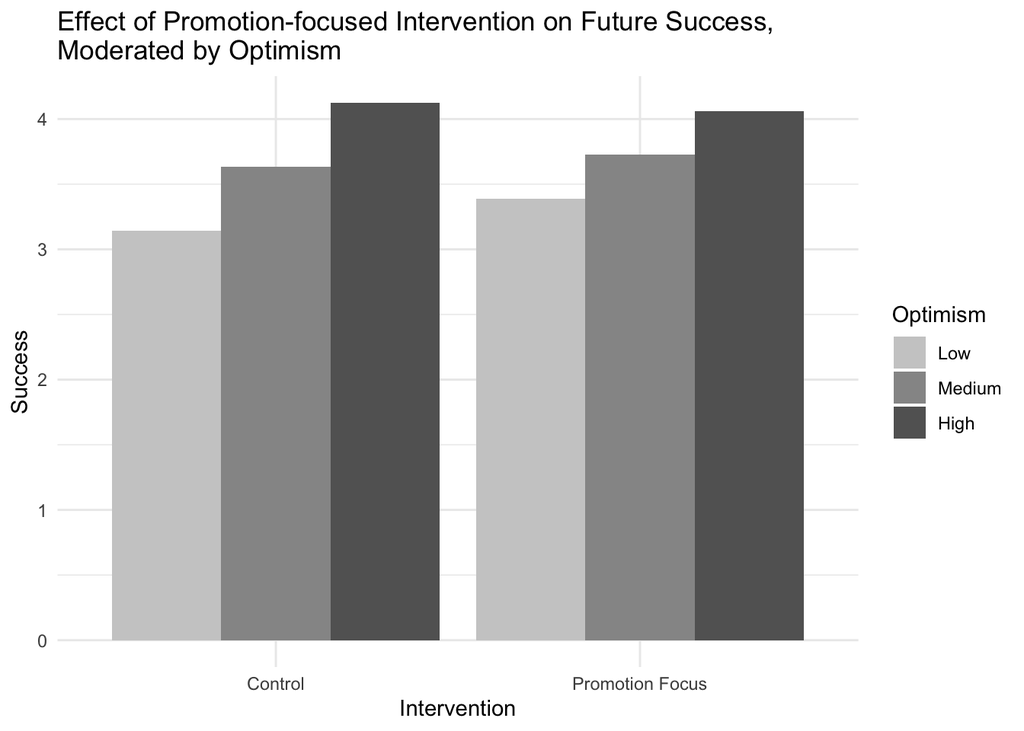

```r
plot_data <- data.frame(
  Intervention = rep(sort(unique(data$Intervention)),each=3),
  Optimism = rep(mean_two_sd_optimism(data),times=2),
  Optimism_Level = rep(names(mean_two_sd_optimism(data)),times=2)
  ) %>%
  mutate(Intervention = factor(Intervention,levels=c("Control","Promotion Focus")),
         Optimism_Level = factor(Optimism_Level,levels=c("Low","Medium","High")))


plot_data$Success <- predict(intv_pro_opt_future,plot_data)

ggplot(plot_data) +
  geom_col(aes(x=Intervention,y=Success,fill=Optimism_Level),position = "dodge") +
  scale_fill_manual(values = c("Low" = "#CCCCCC", "Medium" = "#969696", "High" = "#636363")) +
  labs(title = "Effect of Promotion-focused Intervention on Future Success,\
Moderated by Optimism",
       x = "Intervention", y = "Success",fill="Optimism") +
  theme_minimal()
```

```r
presence_pro_opt_future <- presence_pro_opt_model(data_pred_future)
summary(presence_pro_opt_future)
```

```
##
## Call:
## lm(formula = Success ~ Intervention_Pro * Optimism, data = data)
##
## Residuals:
##      Min       1Q   Median       3Q      Max
## -2.12478 -0.26003  0.03801  0.30328  1.38941
##
## Coefficients:
##                           Estimate Std. Error t value Pr(>|t|)
## (Intercept)                2.23779    0.10248  21.837  < 2e-16 ***
## Intervention_Pro           0.40502    0.14409   2.811  0.00503 **
## Optimism                   0.44414    0.03266  13.598  < 2e-16 ***
## Intervention_Pro:Optimism -0.10015    0.04576  -2.189  0.02885 *
## ---
## Signif. codes:  0 '***' 0.001 '**' 0.01 '*' 0.05 '.' 0.1 ' ' 1
##
## Residual standard error: 0.4659 on 1051 degrees of freedom
##   (145 observations deleted due to missingness)
## Multiple R-squared:  0.2297, Adjusted R-squared:  0.2275
## F-statistic: 104.5 on 3 and 1051 DF,  p-value: < 2.2e-16
```

```r
emm <- emmeans(presence_pro_opt_future, ~ Intervention_Pro | Optimism,
        at = list(Optimism=mean_two_sd_optimism(data_pred_future)))
pairs(emm)
```

```
## Optimism = 1.83:
##  contrast                              estimate     SE   df t.ratio p.value
##  Intervention_Pro0 - Intervention_Pro1  -0.2218 0.0643 1051  -3.452  0.0006
##
## Optimism = 3.08:
##  contrast                              estimate     SE   df t.ratio p.value
##  Intervention_Pro0 - Intervention_Pro1  -0.0961 0.0287 1051  -3.350  0.0008
##
## Optimism = 4.34:
##  contrast                              estimate     SE   df t.ratio p.value
##  Intervention_Pro0 - Intervention_Pro1   0.0296 0.0642 1051   0.462  0.6444
```

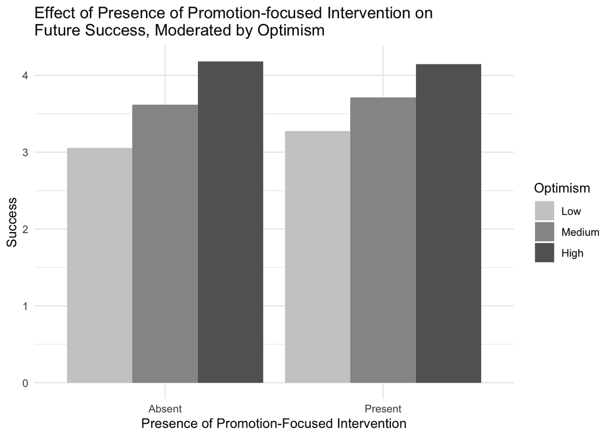

```r
plot_data <- data.frame(
  Intervention_Pro = rep(c(0,1),each=3),
  Optimism = rep(mean_two_sd_optimism(data),times=2),
  Optimism_Level = rep(names(mean_two_sd_optimism(data)),times=2)
  ) %>%
  mutate(Optimism_Level = factor(Optimism_Level,levels=c("Low","Medium","High")))


plot_data$Success <- predict(presence_pro_opt_future,plot_data)
plot_data$Intervention_Pro <- ifelse(plot_data$Intervention_Pro == 0,"Absent","Present")

ggplot(plot_data) +
  geom_col(aes(x=Intervention_Pro,y=Success,fill=Optimism_Level),position = "dodge") +
  scale_fill_manual(values = c("Low" = "#CCCCCC", "Medium" = "#969696", "High" = "#636363")) +
  labs(title = "Effect of Presence of Promotion-focused Intervention on \
Future Success, Moderated by Optimism",
       x = "Presence of Promotion-Focused Intervention", y = "Success",fill="Optimism") +
  theme_minimal()
```

```r
rfs_pro_opt_future <- rfs_pro_opt_model(data_pred_future)
summary(rfs_pro_opt_future)
```

```
##
## Call:
## lm(formula = Success ~ RFS_Promotion * Optimism, data = data)
##
## Residuals:
##      Min       1Q   Median       3Q      Max
## -2.20644 -0.26608  0.03859  0.29636  1.31527
##
## Coefficients:
##                        Estimate Std. Error t value Pr(>|t|)
## (Intercept)             2.53099    0.48321   5.238 1.96e-07 ***
## RFS_Promotion          -0.01497    0.12610  -0.119   0.9055
## Optimism                0.29388    0.15916   1.846   0.0651 .
## RFS_Promotion:Optimism  0.02352    0.04097   0.574   0.5659
## ---
## Signif. codes:  0 '***' 0.001 '**' 0.01 '*' 0.05 '.' 0.1 ' ' 1
##
## Residual standard error: 0.4685 on 1051 degrees of freedom
##   (145 observations deleted due to missingness)
## Multiple R-squared:  0.2209, Adjusted R-squared:  0.2186
## F-statistic: 99.31 on 3 and 1051 DF,  p-value: < 2.2e-16
```

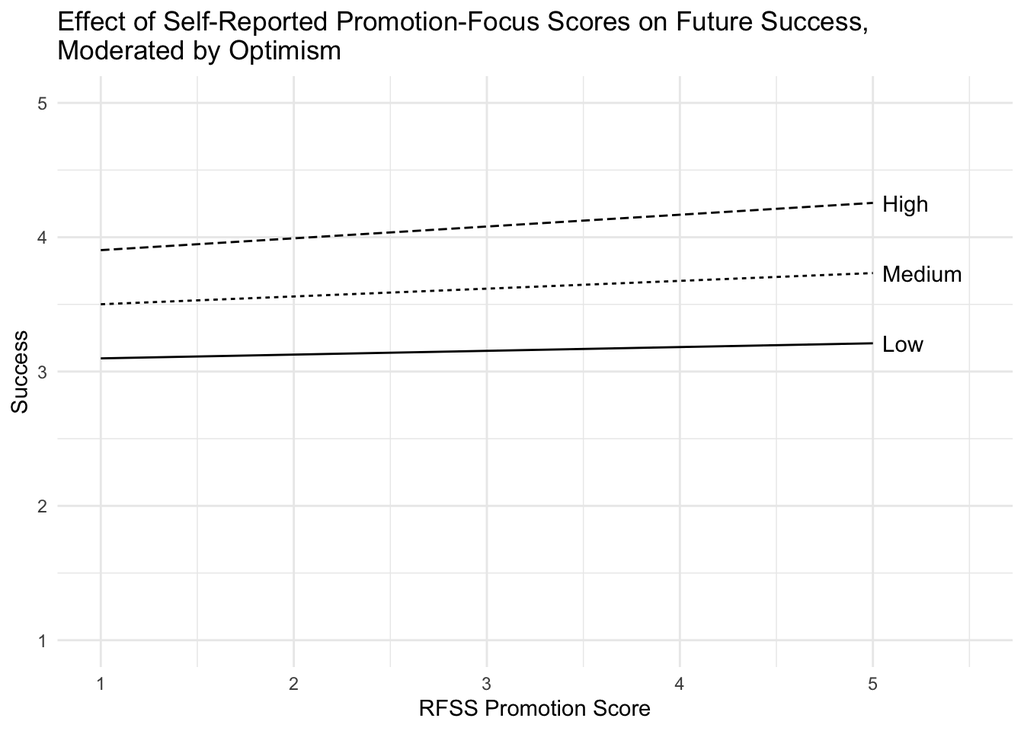

```r
plot_data <- data.frame(
  RFS_Promotion = rep(c(1,5),each=3),
  Optimism = rep(mean_two_sd_optimism(data),times=2),
  Optimism_Level = rep(names(mean_two_sd_optimism(data)),times=2)
  ) %>%
  mutate(Optimism_Level = factor(Optimism_Level,levels=c("Low","Medium","High")))


plot_data$Success <- predict(rfs_pro_opt_future,plot_data)


ggplot(plot_data) +
  geom_path(aes(x=RFS_Promotion,y=Success,linetype=Optimism_Level), show.legend=FALSE) +
  geom_text(aes(x=RFS_Promotion,y=Success,label=Optimism_Level), nudge_x = 0.05,hjust=0,
            data = filter(plot_data, RFS_Promotion == 5)) +
  scale_x_continuous(limits = c(1, 5.5)) +
  scale_y_continuous(limits = c(1, 5)) +
  labs(title = "Effect of Self-Reported Promotion-Focus Scores on Future Success, \
Moderated by Optimism",
       x = "RFSS Promotion Score", y = "Success") +
  theme_minimal()
```

Current states of promotion-focused strategy and optimism do not predict future feelings of success

### Prevention

#### Current

```r
data <- data_pred_curr %>%
  filter_condition(c("Prevention Focus","Control")) %>%
  filter(Time != "S1")
intv_pre_stress_curr <- intv_pre_stress_model(data)
```

```
## # A tibble: 594 × 10
##       ID Interven…¹ Inter…² Inter…³ Time  Success Stress Optim…⁴ RFS_P…⁵ RFS_P…⁶
##    <dbl> <chr>        <dbl>   <dbl> <chr>   <dbl>  <dbl>   <dbl>   <dbl>   <dbl>
##  1     2 Control          0       0 S3       3.62   4.22    4.09    4.25    3.5
##  2     2 Control          0       0 S4       4.21   4.11    4.45    3.62    4.17
##  3     2 Control          0       0 S5      NA     NA      NA      NA      NA
##  4     4 Preventio…       0       1 S3       2.75   4.44    1.55    2.88    3.5
##  5     4 Preventio…       0       1 S4       3.58   3.67    2       2.75    3.67
##  6     4 Preventio…       0       1 S5       3.79   2.78    2.91    2.88    4.17
##  7     7 Control          0       0 S3       3.58   3.89    2.91    3.75    3.67
##  8     7 Control          0       0 S4      NA     NA      NA      NA      NA
##  9     7 Control          0       0 S5      NA     NA      NA      NA      NA
## 10    14 Control          0       0 S3       3.04   3.44    2.45    3.88    3.83
## # … with 584 more rows, and abbreviated variable names ¹Intervention,
## #   ²Intervention_Pro, ³Intervention_Pre, ⁴Optimism, ⁵RFS_Promotion,
## #   ⁶RFS_Prevention
```

```r
summary(intv_pre_stress_curr)
```

```
##
## Call:
## lm(formula = Success ~ Intervention * Stress, data = data)
##
## Residuals:
##      Min       1Q   Median       3Q      Max
## -2.32662 -0.35193  0.09446  0.35924  1.47746
##
## Coefficients:
##                                     Estimate Std. Error t value Pr(>|t|)
## (Intercept)                          3.75847    0.18744  20.052   <2e-16 ***
## InterventionPrevention Focus        -0.55907    0.24563  -2.276   0.0233 *
## Stress                              -0.03088    0.05057  -0.611   0.5418
## InterventionPrevention Focus:Stress  0.13221    0.06644   1.990   0.0471 *
## ---
## Signif. codes:  0 '***' 0.001 '**' 0.01 '*' 0.05 '.' 0.1 ' ' 1
##
## Residual standard error: 0.5544 on 499 degrees of freedom
##   (91 observations deleted due to missingness)
## Multiple R-squared:  0.01708,    Adjusted R-squared:  0.01117
## F-statistic: 2.891 on 3 and 499 DF,  p-value: 0.03501
```

```r
emm <- emmeans(intv_pre_stress_curr, ~ Intervention | Stress,
        at = list(Stress=mean_two_sd_stress(data)))
pairs(emm)
```

```
## Stress = 2.11:
##  contrast                   estimate     SE  df t.ratio p.value
##  Control - Prevention Focus   0.2804 0.1121 499   2.502  0.0127
##
## Stress = 3.62:
##  contrast                   estimate     SE  df t.ratio p.value
##  Control - Prevention Focus   0.0808 0.0495 499   1.634  0.1029
##
## Stress = 5.13:
##  contrast                   estimate     SE  df t.ratio p.value
##  Control - Prevention Focus  -0.1187 0.1116 499  -1.064  0.2878
```

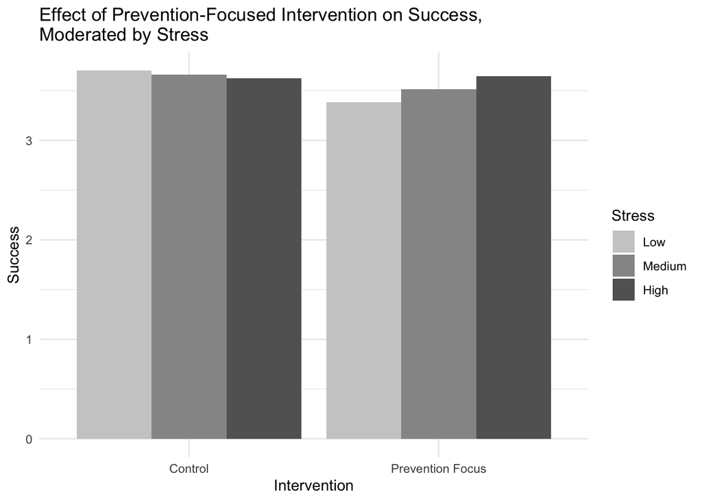

```r
plot_data <- data.frame(
  Intervention = rep(sort(unique(data$Intervention)),each=3),
  Stress = rep(mean_two_sd_optimism(data),times=2),
  Stress_Level = rep(names(mean_two_sd_optimism(data)),times=2)
  ) %>%
  mutate(Intervention = factor(Intervention,levels=c("Control","Prevention Focus")),
         Stress_Level = factor(Stress_Level,levels=c("Low","Medium","High")))


plot_data$Success <- predict(intv_pre_stress_curr,plot_data)

ggplot(plot_data) +
  geom_col(aes(x=Intervention,y=Success,fill=Stress_Level),position = "dodge") +
  scale_fill_manual(values = c("Low" = "#CCCCCC", "Medium" = "#969696", "High" = "#636363")) +
  labs(title = "Effect of Prevention-Focused Intervention on Success,\
Moderated by Stress",
       x = "Intervention", y = "Success",fill="Stress") +
  theme_minimal()
```

```r
data <- data_pred_curr %>%
  filter(Time != "S1")

presence_pre_stress_curr <- presence_pre_stress_model(data)
summary(presence_pre_stress_curr)
```

```
##
## Call:
## lm(formula = Success ~ Intervention_Pre * Stress, data = data)
##
## Residuals:
##      Min       1Q   Median       3Q      Max
## -2.48981 -0.31968  0.05802  0.33409  1.38987
##
## Coefficients:
##                         Estimate Std. Error t value Pr(>|t|)
## (Intercept)              3.89375    0.12489  31.177  < 2e-16 ***
## Intervention_Pre        -0.44330    0.17043  -2.601  0.00943 **
## Stress                  -0.05672    0.03388  -1.674  0.09442 .
## Intervention_Pre:Stress  0.10534    0.04572   2.304  0.02142 *
## ---
## Signif. codes:  0 '***' 0.001 '**' 0.01 '*' 0.05 '.' 0.1 ' ' 1
##
## Residual standard error: 0.5291 on 1015 degrees of freedom
##   (181 observations deleted due to missingness)
## Multiple R-squared:  0.008184,   Adjusted R-squared:  0.005253
## F-statistic: 2.792 on 3 and 1015 DF,  p-value: 0.03939
```

```r
emm <- emmeans(presence_pre_stress_curr, ~ Intervention_Pre | Stress,
        at = list(Stress=mean_two_sd_stress(data)))
pairs(emm)
```

```
## Stress = 2.20:
##  contrast                              estimate     SE   df t.ratio p.value
##  Intervention_Pre0 - Intervention_Pre1   0.2114 0.0743 1015   2.843  0.0046
##
## Stress = 3.66:
##  contrast                              estimate     SE   df t.ratio p.value
##  Intervention_Pre0 - Intervention_Pre1   0.0576 0.0332 1015   1.733  0.0835
##
## Stress = 5.12:
##  contrast                              estimate     SE   df t.ratio p.value
##  Intervention_Pre0 - Intervention_Pre1  -0.0963 0.0748 1015  -1.287  0.1984
```

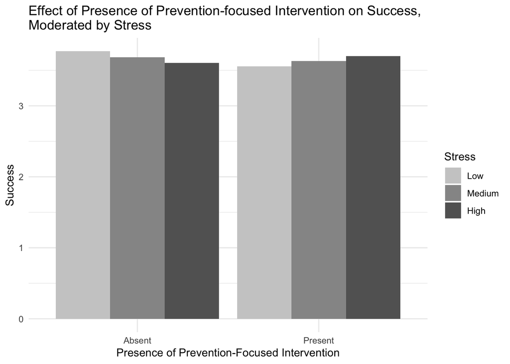

```r
plot_data <- data.frame(
  Intervention_Pre = rep(c(0,1),each=3),
  Stress= rep(mean_two_sd_stress(data),times=2),
  Stress_Level = rep(names(mean_two_sd_stress(data)),times=2)
  ) %>%
  mutate(Stress_Level = factor(Stress_Level,levels=c("Low","Medium","High")))

plot_data$Success <- predict(presence_pre_stress_curr,plot_data)
plot_data$Intervention_Pre <- ifelse(plot_data$Intervention_Pre == 0,"Absent","Present")

ggplot(plot_data) +
  geom_col(aes(x=Intervention_Pre,y=Success,fill=Stress_Level),position = "dodge") +
  scale_fill_manual(values = c("Low" = "#CCCCCC", "Medium" = "#969696", "High" = "#636363")) +
  labs(title = "Effect of Presence of Prevention-focused Intervention on Success,\
Moderated by Stress",
       x = "Presence of Prevention-Focused Intervention", y = "Success",fill="Stress") +
  theme_minimal()
```

```r
rfs_pre_stress_curr <- rfs_pre_stress_model(data_pred_curr)
summary(rfs_pre_stress_curr)
```

```
##
## Call:
## lm(formula = Success ~ RFS_Prevention * Stress, data = data)
##
## Residuals:
##      Min       1Q   Median       3Q      Max
## -2.53130 -0.35036  0.05972  0.34484  1.47476
##
## Coefficients:
##                       Estimate Std. Error t value Pr(>|t|)
## (Intercept)            2.89093    0.39979   7.231 7.82e-13 ***
## RFS_Prevention         0.20671    0.11431   1.808   0.0708 .
## Stress                 0.21266    0.10617   2.003   0.0454 *
## RFS_Prevention:Stress -0.05850    0.03025  -1.934   0.0533 .
## ---
## Signif. codes:  0 '***' 0.001 '**' 0.01 '*' 0.05 '.' 0.1 ' ' 1
##
## Residual standard error: 0.5408 on 1415 degrees of freedom
##   (181 observations deleted due to missingness)
## Multiple R-squared:  0.002959,   Adjusted R-squared:  0.0008449
## F-statistic:   1.4 on 3 and 1415 DF,  p-value: 0.2412
```

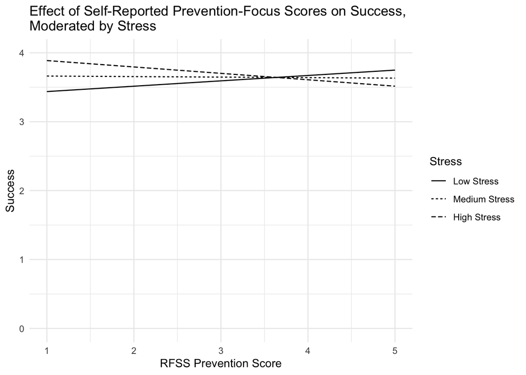

```r
plot_data <- data.frame(
  RFS_Prevention = rep(c(1,5),each=3),
  Stress = rep(mean_two_sd_stress(data),times=2),
  Stress_Level = rep(names(mean_two_sd_stress(data)),times=2)
  ) %>%
  mutate(Stress_Level = factor(Stress_Level,
                               labels=c("Low Stress", "Medium Stress", "High Stress"),
                               levels=c("Low","Medium","High")))


plot_data$Success <- predict(rfs_pre_stress_curr,plot_data)


ggplot(plot_data) +
  geom_path(aes(x=RFS_Prevention,y=Success,linetype=Stress_Level)) +
  # geom_text(aes(x=RFS_Prevention,y=Success,label=Stress_Level), nudge_x = 0.05,hjust=0,
  #           data = filter(plot_data, RFS_Prevention == 5)) +
  # scale_x_continuous(limits = c(1, 6),breaks = seq(1, 5, by = 1)) +
  scale_y_continuous(limits = c(0, 4)) +
  labs(title = "Effect of Self-Reported Prevention-Focus Scores on Success, \
Moderated by Stress", linetype = "Stress",
       x = "RFSS Prevention Score", y = "Success") +
  theme_minimal()
```

Feelings of success are higher among participants higher among participants who are more stressed. Non significant Stress x RFS_pre interaction

## Prediction

```r
data <- data_pred_future %>%
  filter_condition(c("Prevention Focus","Control"))
intv_pre_stress_future <- intv_pre_stress_model(data)
```

```
## # A tibble: 594 × 15
##       ID Inter…¹ Inter…² Inter…³ pred_…⁴ Time_…⁵ Time_…⁶ Time_…⁷ Time_…⁸ Time_…⁹
##    <dbl> <chr>     <dbl>   <dbl> <chr>     <dbl>   <dbl>   <dbl>   <dbl>   <dbl>
##  1     2 Control       0       0 S3            3       1       1       1       1
##  2     2 Control       0       0 S4            4       3       3       3       3
##  3     2 Control       0       0 S5            5       4       4       4       4
##  4     4 Preven…       0       1 S3            3       1       1       1       1
##  5     4 Preven…       0       1 S4            4       3       3       3       3
##  6     4 Preven…       0       1 S5            5       4       4       4       4
##  7     7 Control       0       0 S3            3       1       1       1       1
##  8     7 Control       0       0 S4            4       3       3       3       3
##  9     7 Control       0       0 S5            5       4       4       4       4
## 10    14 Control       0       0 S3            3       1       1       1       1
## # … with 584 more rows, 5 more variables: Success <dbl>, Stress <dbl>,
## #   Optimism <dbl>, RFS_Promotion <dbl>, RFS_Prevention <dbl>, and abbreviated
## #   variable names ¹Intervention, ²Intervention_Pro, ³Intervention_Pre,
## #   ⁴pred_for, ⁵Time_success, ⁶Time_stress, ⁷Time_opt, ⁸Time_RFS_pro,
## #   ⁹Time_RFS_pre
```

```r
summary(intv_pre_stress_future)
```

```
##
## Call:
## lm(formula = Success ~ Intervention * Stress, data = data)
##
## Residuals:
##      Min       1Q   Median       3Q      Max
## -2.25509 -0.36845  0.09356  0.35651  1.44204
##
## Coefficients:
##                                     Estimate Std. Error t value Pr(>|t|)
## (Intercept)                          3.52145    0.16981  20.738   <2e-16 ***
## InterventionPrevention Focus        -0.51413    0.23347  -2.202   0.0281 *
## Stress                               0.03230    0.04617   0.700   0.4845
## InterventionPrevention Focus:Stress  0.12093    0.06304   1.918   0.0556 .
## ---
## Signif. codes:  0 '***' 0.001 '**' 0.01 '*' 0.05 '.' 0.1 ' ' 1
##
## Residual standard error: 0.5485 on 513 degrees of freedom
##   (77 observations deleted due to missingness)
## Multiple R-squared:  0.02918,    Adjusted R-squared:  0.02351
## F-statistic:  5.14 on 3 and 513 DF,  p-value: 0.001647
```

```r
emm <- emmeans(intv_pre_stress_future, ~ Intervention | Stress,
        at = list(Stress=mean_two_sd_stress(data)))
pairs(emm)
```

```
## Stress = 2.08:
##  contrast                   estimate     SE  df t.ratio p.value
##  Control - Prevention Focus   0.2629 0.1087 513   2.417  0.0160
##
## Stress = 3.62:
##  contrast                   estimate     SE  df t.ratio p.value
##  Control - Prevention Focus   0.0761 0.0483 513   1.576  0.1157
##
## Stress = 5.17:
##  contrast                   estimate     SE  df t.ratio p.value
##  Control - Prevention Focus  -0.1107 0.1087 513  -1.019  0.3086
```

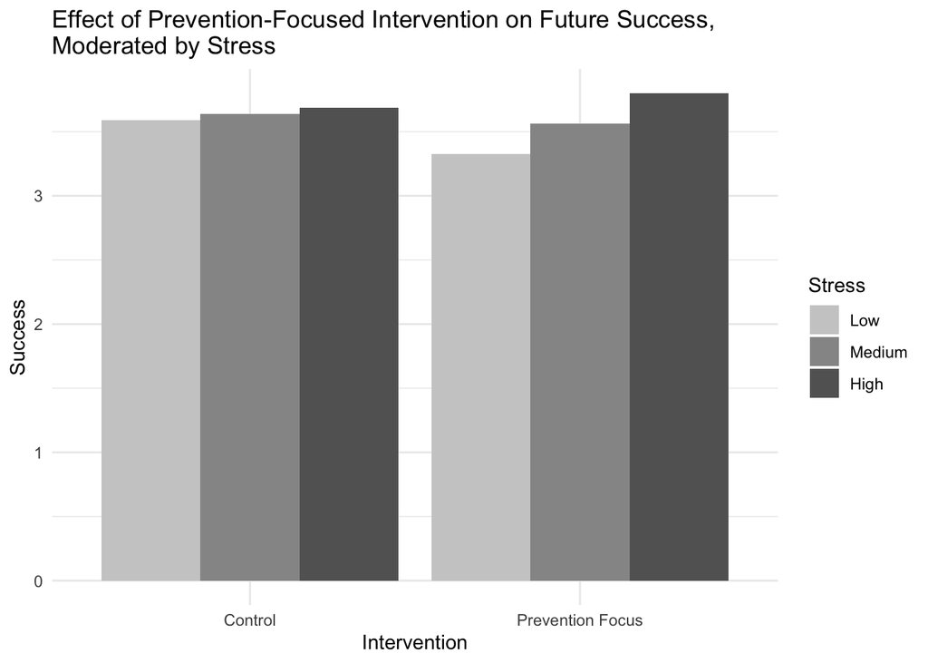

```r
plot_data <- data.frame(
  Intervention = rep(sort(unique(data$Intervention)),each=3),
  Stress = rep(mean_two_sd_stress(data),times=2),
  Stress_Level = rep(names(mean_two_sd_stress(data)),times=2)
  ) %>%
  mutate(Intervention = factor(Intervention,levels=c("Control","Prevention Focus")),
         Stress_Level = factor(Stress_Level,levels=c("Low","Medium","High")))
plot_data$Success <- predict(intv_pre_stress_future,plot_data)

ggplot(plot_data) +
  geom_col(aes(x=Intervention,y=Success,fill=Stress_Level),position = "dodge") +
  scale_fill_manual(values = c("Low" = "#CCCCCC", "Medium" = "#969696", "High" = "#636363")) +
  labs(title = "Effect of Prevention-Focused Intervention on Future Success, \
Moderated by Stress",
       x = "Intervention", y = "Success",fill="Stress") +
  theme_minimal()
```

Prevention-focused intervention decreases feelings of success. Increased stress has no significant effect on feelings of success. Stress increases feelings of success among individuals who underwent the prevention-focused intervention.

```r
presence_pre_stress_future <- presence_pre_stress_model(data_pred_future)
summary(presence_pre_stress_future)
```

```
##
## Call:
## lm(formula = Success ~ Intervention_Pre * Stress, data = data)
##
## Residuals:
##      Min       1Q   Median       3Q      Max
## -2.41702 -0.31966  0.05658  0.32650  1.40558
##
## Coefficients:
##                         Estimate Std. Error t value Pr(>|t|)
## (Intercept)              3.82524    0.11744  32.572  < 2e-16 ***
## Intervention_Pre        -0.54889    0.16310  -3.365 0.000793 ***
## Stress                  -0.03930    0.03205  -1.226 0.220426
## Intervention_Pre:Stress  0.13584    0.04390   3.094 0.002027 **
## ---
## Signif. codes:  0 '***' 0.001 '**' 0.01 '*' 0.05 '.' 0.1 ' ' 1
##
## Residual standard error: 0.5276 on 1038 degrees of freedom
##   (158 observations deleted due to missingness)
## Multiple R-squared:  0.01358,    Adjusted R-squared:  0.01073
## F-statistic: 4.765 on 3 and 1038 DF,  p-value: 0.002641
```

```r
library(emmeans)
emm <- emmeans(presence_pre_stress_future, ~ Intervention_Pre | Stress,
        at = list(Stress=mean_two_sd_stress(data_pred_future)))
pairs(emm)
```

```
## Stress = 2.15:
##  contrast                              estimate     SE   df t.ratio p.value
##  Intervention_Pre0 - Intervention_Pre1   0.2575 0.0733 1038   3.511  0.0005
##
## Stress = 3.65:
##  contrast                              estimate     SE   df t.ratio p.value
##  Intervention_Pre0 - Intervention_Pre1   0.0537 0.0328 1038   1.638  0.1017
##
## Stress = 5.15:
##  contrast                              estimate     SE   df t.ratio p.value
##  Intervention_Pre0 - Intervention_Pre1  -0.1501 0.0738 1038  -2.033  0.0423
```

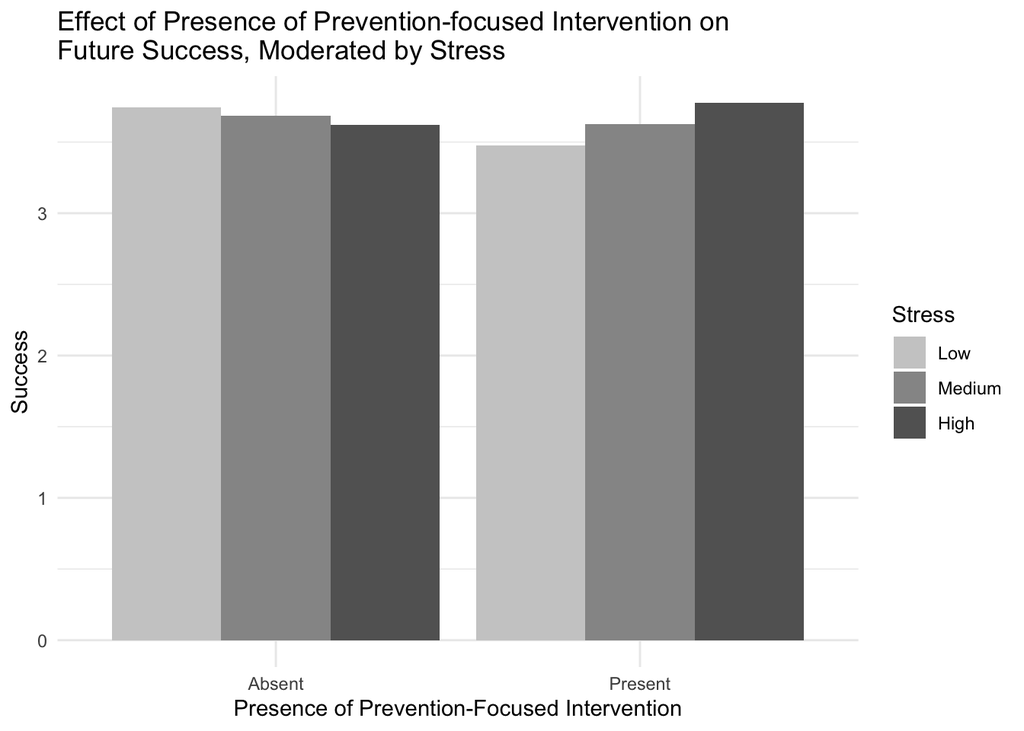

```r
plot_data <- data.frame(
  Intervention_Pre = rep(c(0,1),each=3),
  Stress = rep(mean_two_sd_stress(data),times=2),
  Stress_Level = rep(names(mean_two_sd_stress(data)),times=2)
  ) %>%
  mutate(Stress_Level = factor(Stress_Level,levels=c("Low","Medium","High")))

plot_data$Success <-predict(presence_pre_stress_future,plot_data)
plot_data$Intervention_Pre <- ifelse(plot_data$Intervention_Pre == 0,"Absent","Present")

ggplot(plot_data) +
  geom_col(aes(x=Intervention_Pre,y=Success,fill=Stress_Level),position = "dodge") +
  scale_fill_manual(values = c("Low" = "#CCCCCC", "Medium" = "#969696", "High" = "#636363")) +
  labs(title = "Effect of Presence of Prevention-focused Intervention on \
Future Success, Moderated by Stress",
       x = "Presence of Prevention-Focused Intervention", y = "Success",fill="Stress") +
  theme_minimal()
```

```r
rfs_pre_stress_future <- rfs_pre_stress_model(data_pred_future)
summary(rfs_pre_stress_future)
```

```
##
## Call:
## lm(formula = Success ~ RFS_Prevention * Stress, data = data)
##
## Residuals:
##      Min       1Q   Median       3Q      Max
## -2.52789 -0.32860  0.05854  0.33686  1.36564
##
## Coefficients:
##                       Estimate Std. Error t value Pr(>|t|)
## (Intercept)            2.96109    0.44987   6.582 7.35e-11 ***
## RFS_Prevention         0.16982    0.12877   1.319    0.188
## Stress                 0.19758    0.12017   1.644    0.100
## RFS_Prevention:Stress -0.04839    0.03428  -1.412    0.158
## ---
## Signif. codes:  0 '***' 0.001 '**' 0.01 '*' 0.05 '.' 0.1 ' ' 1
##
## Residual standard error: 0.5302 on 1038 degrees of freedom
##   (158 observations deleted due to missingness)
## Multiple R-squared:  0.003852,   Adjusted R-squared:  0.0009727
## F-statistic: 1.338 on 3 and 1038 DF,  p-value: 0.2606
```

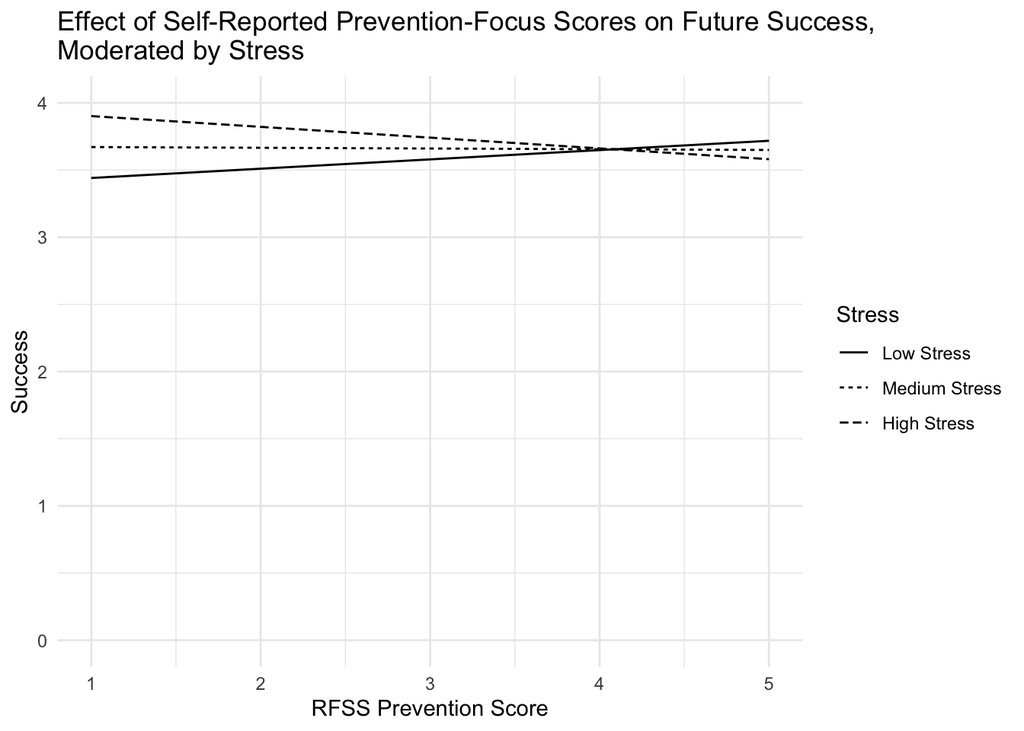

```r
plot_data <- data.frame(
  RFS_Prevention = rep(c(1,5),each=3),
  Stress = rep(mean_two_sd_stress(data),times=2),
  Stress_Level = rep(names(mean_two_sd_stress(data)),times=2)
  ) %>%
  mutate(Stress_Level = factor(Stress_Level,
                               labels=c("Low Stress", "Medium Stress", "High Stress"),
                               levels=c("Low","Medium","High")))


plot_data$Success <- predict(rfs_pre_stress_future,plot_data)


ggplot(plot_data) +
  geom_path(aes(x=RFS_Prevention,y=Success,linetype=Stress_Level)) +
  # geom_text(aes(x=RFS_Prevention,y=Success,label=Stress_Level), nudge_x = 0.05,
  #           ,hjust=0,
  #           data = filter(plot_data, RFS_Prevention == 5)) +
  # scale_x_continuous(limits = c(1, 6),breaks = seq(1, 5, by = 1)) +
  scale_y_continuous(limits = c(0, 4)) +
  labs(title = "Effect of Self-Reported Prevention-Focus Scores on Future Success, \
Moderated by Stress", linetype = "Stress",
       x = "RFSS Prevention Score", y = "Success") +
  theme_minimal()
```

Current states of prevention-focused strategy and stress do not predict future feelings of success